Introduction Microsimulation Machine Learning Models Reflection References

# Machine Learning Models - Estimating Voter Turnout

## Data pre-processing

To utilize the ASEC data with the estimated new income amounts calculated under the microsimulation model, refactoring is required. The CPS voter supplement data, which we intend to utilize for the machine learning model, is structed differently from the ASEC data. Income is a categorical variable in the CPS and race, education, employment status, all utilize different labels for each category. As such, the code below refactors both the ASEC and CPS data to ensure they are structured the same to utilize in the machine learning model.

**Data loading and cleaning**

```r
# Loading in packages
library(tidymodels)
library(tidyverse)
library(here)

# Loading in data

asec_2022 <-

  read_csv("/Users/mia.minkin/Downloads/Georgetown MPP/Classes/Year 2/Fall 2023/ds_2/final_project/data/asec_individual.csv") %>%

  # Subsetting to necessary variables

    filter(YEAR == 2022) %>%

  select(
    SERIAL,
    FTOTVAL,
    AGE,
    SEX,
    RACE,
    EMPSTAT,
    MARST,
    EDUC,
    NCHILD,
    NCHLT5,
    HWTFINL,
    WTFINL,
    ASECWTH) %>%

  filter(
    !FTOTVAL == "NA",
    !FTOTVAL < 0,
    !AGE < 18,
    !SEX == 9,
    !EMPSTAT == 00,
    !RACE == 999,
    !MARST == 9,
    !EDUC == 999,
    !EDUC == 000,
    !EDUC == 001) %>%

  mutate(
    MARST =
      case_when(
        MARST == 1 ~ 1,
        TRUE ~ 0)) %>%

  rename(
    label = SERIAL,
    hh_income = FTOTVAL,
    sex = SEX,
    marital_status = MARST,
    emp_status = EMPSTAT,
    age = AGE,
    race = RACE,
    education = EDUC,
    tot_children = NCHILD,
    young_children = NCHLT5) %>%

  mutate(
    old_children = tot_children - young_children) %>%

  distinct(label, .keep_all = TRUE)

#' Calculating the total child tax credit benefit for families under the American Rescue Plan Act's expanded child tax credit
#'
#' @param hh_income Numeric total of family income in a year
#' @param marital_status Binary variable for if parents are married or not
#' @param old_children Numeric total number of children 6 - 18
#' @param young_children Numeric total number of children under age 6
#'
#' @return Numeric benefit in dollars
#'

arpa_tax_credit <- function(hh_income, marital_status, old_children, young_children){

  # Assumption: Maximum income for full benefit = $75,000 if one head of household OR $150,000 if married household

  mod_income <-
    if_else(
      condition = marital_status == 1,
      true = pmax(hh_income - 150000, 0),
      false = pmax(hh_income - 75000, 0))

  # Benefit per child

  benefit <-

    case_when(

      # Married couple, income < 400k, only older children
      marital_status == 1 & hh_income < 400000 & old_children >= 1 & young_children == 0 ~
        pmax(2000, (3000 * old_children) - 0.05 * mod_income),

      # Married couple, income > 400k, only older children
      marital_status == 1 & hh_income > 400000 & old_children >= 1 & young_children == 0 ~
        pmax(0, (3000 * old_children) - 0.05 * mod_income),

      # Single household, income < 200k, only older children
      marital_status == 0 & hh_income < 200000 & old_children >= 1 & young_children == 0 ~
        pmax(2000, (3000 * old_children) - 0.05 * mod_income),

      # Single household, income > 200k, only older children
      marital_status == 0 & hh_income > 200000 & old_children >= 1 & young_children == 0 ~
        pmax(0, (3000 * old_children) - 0.05 * mod_income),

      # Married couple, income < 400k, only young children
      marital_status == 1 & hh_income < 400000 & old_children == 0 & young_children >= 1 ~
        pmax(2000, (3600 * young_children) - 0.05 * mod_income),

      # Married couple, income > 400k, only young children
      marital_status == 1 & hh_income < 400000 & old_children == 0 & young_children >= 1 ~
        pmax(0, (3600 * young_children) - 0.05 * mod_income),

      # Single household, income < 200k, only young children
      marital_status == 0 & hh_income < 200000 & old_children == 0 & young_children >= 1 ~
        pmax(2000, (3600 * young_children) - 0.05 * mod_income),

      # Single household, income > 200k, only young children
      marital_status == 0 & hh_income > 200000 & old_children == 0 & young_children >= 1 ~
        pmax(0, (3600 * young_children) - 0.05 * mod_income),

      # Married couple, income < 400k, older and young children
      marital_status == 1 & hh_income < 400000 & old_children >= 1 & young_children >= 1 ~
        pmax(2000, ((3000 * old_children) + (3600 * young_children)) - 0.05 * mod_income),

      # Married couple, income > 400k, older and young children
      marital_status == 1 & hh_income > 400000 & old_children >= 1 & young_children >= 1 ~
        pmax(0, ((3000 * old_children) + (3600 * young_children)) - 0.05 * mod_income),

      # Single couple, income < 200k, older and young children
      marital_status == 0 & hh_income < 200000 & old_children >= 1 & young_children >= 1 ~
        pmax(2000, ((3000 * old_children) + (3600 * young_children)) - 0.05 * mod_income),

      # Single couple, income > 200k, older and young children
      marital_status == 0  & hh_income > 200000 & old_children >= 1 & young_children >= 1 ~
        pmax(0, ((3000 * old_children) + (3600 * young_children)) - 0.05 * mod_income),

      TRUE ~ 0)

  return(benefit)

}

asec_arpa <-
  asec_2022 %>%
  select(hh_income, marital_status, young_children, old_children)

arpa_credit <-
  asec_arpa %>%
  mutate(
    benefit = pmap_dbl(asec_arpa, arpa_tax_credit))

#' Calculating the total child tax credit benefit for families under the American Rescue Plan Act's expanded child tax credit
#'
#' @param hh_income Numeric total of family income in a year
#' @param marital_status Binary variable for if parents are married or not
#' @param tot_children Number of qualifying children
#'
#' @return Numeric benefit in dollars
#'

child_tax_credit <- function(hh_income, marital_status, tot_children){

  # Assumption: Maximum income for full benefit = $200,000 if one head of household OR $400,000 if married household

  mod_income <-
    if_else(
      condition = marital_status == 1,
      true = pmax(hh_income - 400000, 0),
      false = pmax(hh_income - 200000, 0))

  # Benefit per child

  benefit <-

    case_when(

      # Married couple
      marital_status == 1 ~ pmax(0, (2000 * tot_children) - 0.05 * mod_income),

      # Single household
      marital_status == 0 ~ pmax(0, (2000 * tot_children) - 0.05 * mod_income),

      TRUE ~ 0)

  return(benefit)

}

asec_ctc <-
  asec_2022 %>%
  select(marital_status, hh_income, tot_children)

normal_ctc <-
  asec_ctc %>%
  mutate(
    benefit = pmap_dbl(asec_ctc, child_tax_credit))

normal_ctc <-
  normal_ctc %>%
  mutate(
    credit = "normal_ctc")

arpa_credit <-
  arpa_credit %>%
  mutate(
    credit = "arpa_ctc")

credits_combined <-
  bind_rows(normal_ctc, arpa_credit)

credits_combined %>%

  summarize(
    mean_benefit = mean(benefit),
    .by = credit) %>%

  ggplot() +
  geom_col(
    aes(x = credit,
        y = mean_benefit),
    fill = "#add8e6") +

  labs(
    title = "Estimating mean benefit of federal child tax credit",
    subtitle = "Comparing the expanded CTC versus the normal CTC",
    x = "Credit type",
    y = "Mean benefit") +

  theme_classic()
```

[output not shown]

**Pre-processing of ASEC data**

```r
# Appending ASEC data - adding benefit to total income for income estimated under microsimulation

asec_mod_inc <-

  bind_cols(
    asec_2022,
    arpa_credit$benefit,
    normal_ctc$benefit) %>%

  mutate(
    arpa_benefit = ...15,
    ctc_reg = ...16) %>%

  select(
    arpa_benefit,
    ctc_reg,
    hh_income) %>%

  mutate(
    arpa_tot_inc = hh_income + arpa_benefit,
    ctc_reg_tot_inc = hh_income + ctc_reg) %>%

  select(
    arpa_tot_inc,
    ctc_reg_tot_inc,
    - hh_income)

# Appending back to original data set
asec_full <-
  bind_cols(
    asec_2022,
    asec_mod_inc)


# Refactoring ASEC to match CPS structure

asec_refactored <-

  asec_full %>%

  rename(
    weight = ASECWTH) %>%

  select(
    weight,
    age,
    sex,
    race,
    emp_status,
    education,
    marital_status,
    hh_income,
    arpa_tot_inc,
    ctc_reg_tot_inc) %>%

  # Refactoring income

  mutate(

    hh_income =
      case_when(
        hh_income < 5000 ~ 1,
        hh_income <= 7499 ~ 2,
        hh_income <= 9999 ~ 3,
        hh_income <= 12499 ~ 4,
        hh_income <= 14999 ~ 5,
        hh_income <= 19999 ~ 6,
        hh_income <= 24999 ~ 7,
        hh_income <= 29999 ~ 8,
        hh_income <= 34999 ~ 9,
        hh_income <= 39999 ~ 10,
        hh_income <= 49999 ~ 11,
        hh_income <= 59999 ~ 12,
        hh_income <= 74999 ~ 13,
        hh_income <= 99999 ~ 14,
        hh_income <= 149999 ~ 15,
        hh_income >= 150000 ~ 16),

    arpa_tot_inc =
      case_when(
        arpa_tot_inc < 5000 ~ 1,
        arpa_tot_inc <= 7499 ~ 2,
        arpa_tot_inc <= 9999 ~ 3,
        arpa_tot_inc <= 12499 ~ 4,
        arpa_tot_inc <= 14999 ~ 5,
        arpa_tot_inc <= 19999 ~ 6,
        arpa_tot_inc <= 24999 ~ 7,
        arpa_tot_inc <= 29999 ~ 8,
        arpa_tot_inc <= 34999 ~ 9,
        arpa_tot_inc <= 39999 ~ 10,
        arpa_tot_inc <= 49999 ~ 11,
        arpa_tot_inc <= 59999 ~ 12,
        arpa_tot_inc <= 74999 ~ 13,
        arpa_tot_inc <= 99999 ~ 14,
        arpa_tot_inc <= 149999 ~ 15,
        arpa_tot_inc >= 150000 ~ 16),

    ctc_reg_tot_inc =
      case_when(
        ctc_reg_tot_inc < 5000 ~ 1,
        ctc_reg_tot_inc <= 7499 ~ 2,
        ctc_reg_tot_inc <= 9999 ~ 3,
        ctc_reg_tot_inc <= 12499 ~ 4,
        ctc_reg_tot_inc <= 14999 ~ 5,
        ctc_reg_tot_inc <= 19999 ~ 6,
        ctc_reg_tot_inc <= 24999 ~ 7,
        ctc_reg_tot_inc <= 29999 ~ 8,
        ctc_reg_tot_inc <= 34999 ~ 9,
        ctc_reg_tot_inc <= 39999 ~ 10,
        ctc_reg_tot_inc <= 49999 ~ 11,
        ctc_reg_tot_inc <= 59999 ~ 12,
        ctc_reg_tot_inc <= 74999 ~ 13,
        ctc_reg_tot_inc <= 99999 ~ 14,
        ctc_reg_tot_inc <= 149999 ~ 15,
        ctc_reg_tot_inc >= 150000 ~ 16)) %>%

  # Refactoring education (1 = no hs degree, 2 = hs diploma, 3 = some college,
  # 4 = bachelor's, 5 = higher degree)

  mutate(
    education =
      case_when(
        education <= 072 ~ 1,
        education == 73 ~ 2,
        education <= 110 ~ 3,
        education <= 122 ~ 4,
        education <= 125 ~ 5)) %>%

  # Refactoring race (1 = White, 2 = Black, 3 = American indian, 4 = Asian, 5 = 2 or more races and other)

  mutate(
    race =
      case_when(
        race == 100 ~ 1,
        race == 200 ~ 2,
        race == 300 ~ 3,
        race == 650 ~ 4,
        race == 651 ~ 4,
        race == 652 ~ 4,
        race > 660 ~ 5)) %>%

  # Refactoring employment (1 = employed, 2 = unemployed)

  mutate(
    emp_status =
      case_when(
        emp_status == 01 ~ 1,
        emp_status == 02 ~ 1,
        emp_status == 10 ~ 1,
        emp_status == 12 ~ 1,
        emp_status <= 36 ~ 0))
```

**Pre-processing of CPS data**

```r
cps <- read_csv(here("data/cps_supp.csv")) %>%

  select(
    PWSSWGT,
    PRTAGE,
    PEEDUCA,
    PEMARITL,
    PESEX,
    PEMLR,
    PTDTRACE,
    HEFAMINC,
    PES2,
    PES1) %>%

  mutate(
    weight = PWSSWGT,
    education = PEEDUCA,
    age = PRTAGE,
    marital_status = PEMARITL,
    sex = PESEX,
    emp_status = PEMLR,
    race = PTDTRACE,
    hh_income = HEFAMINC,
    voted = PES1) %>%

  filter(
    !education == -1,
    !age < 0,
    !marital_status == -1,
    !emp_status == -1,
    !race == -1,
    !hh_income == -1,
    !voted < 0) %>%

  select(
    weight,
    age,
    sex,
    race,
    education,
    marital_status,
    emp_status,
    hh_income,
    voted) %>%

   # Refactoring education (1 = no hs degree, 2 = hs diploma, 3 = some college, # 4 = bachelor's, 5 = higher degree)

  mutate(
    education =
      case_when(
        education <= 38 ~ 1,
        education == 39 ~ 2,
        education <= 42 ~ 3,
        education == 43 ~ 4,
        education <= 46 ~ 5)) %>%

  # Refactoring race (1 = White, 2 = Black, 3 = American indian, 4 = Asian, 5 = 2 or more races and other)

  mutate(
    race =
      case_when(
        race == 01 ~ 1,
        race == 02 ~ 2,
        race == 03 ~ 3,
        race == 04 ~ 4,
        race == 05 ~ 4,
        race <= 26 ~ 5)) %>%

  # Refactoring employment (1 = employed, 2 = unemployed)

  mutate(
    emp_status =
      case_when(
        emp_status == 1 ~ 1,
        emp_status == 2 ~ 1,
        emp_status <= 7 ~ 0))
```

## Exploratory Data Analysis - Voter turnout rate by Income Level

*Weights have been applied*

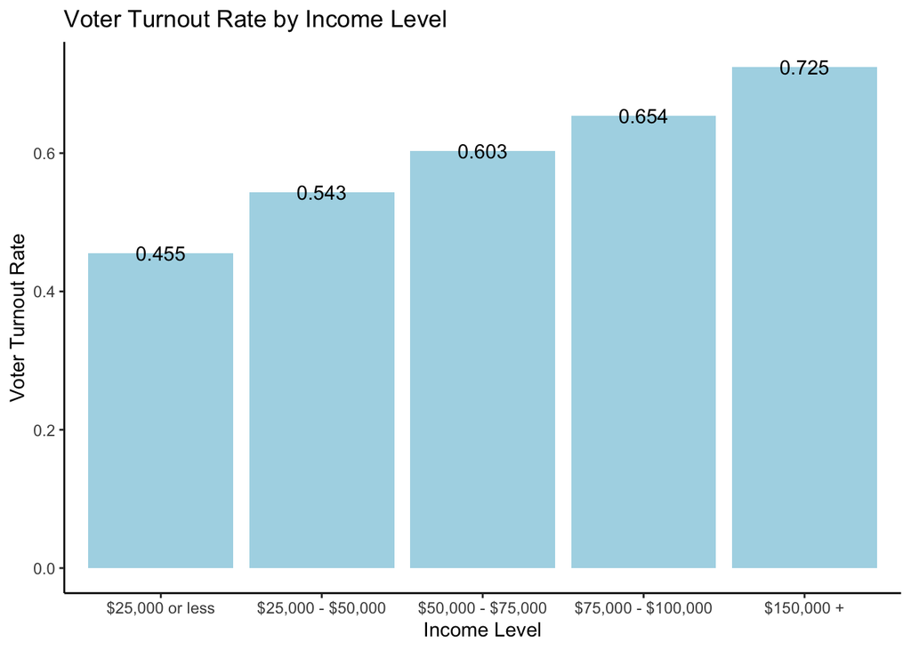

```r
cps <-
  cps %>%
  mutate(voted = as.factor(voted))

# Voter turnout rate by income level

cps_voted <-

  cps %>%

  mutate(
    inc_grouped =
      case_when(
        hh_income <= 7 ~ "$25,000 or less",
        hh_income <= 11 ~ "$25,000 - $50,000",
        hh_income <= 13 ~ "$50,000 - $75,000",
        hh_income == 14 ~ "$75,000 - $100,000",
        hh_income <= 16 ~ "$150,000 +")) %>%

  filter(voted == 1) %>%

  summarize(
    total = sum(weight),
    .by = c(inc_grouped)) %>%

  mutate(voted = "voted")

cps_no_voted <-

  cps %>%

  mutate(
    inc_grouped =
      case_when(
        hh_income <= 7 ~ "$25,000 or less",
        hh_income <= 11 ~ "$25,000 - $50,000",
        hh_income <= 13 ~ "$50,000 - $75,000",
        hh_income == 14 ~ "$75,000 - $100,000",
        hh_income <= 16 ~ "$150,000 +")) %>%

    filter(voted == 2) %>%

  summarize(
    total = sum(weight),
    .by = c(inc_grouped)) %>%

  mutate(voted = "no vote")

cps_turnout <-
  bind_rows(
    cps_voted,
    cps_no_voted) %>%

  arrange(inc_grouped) %>%

  pivot_wider(
    values_from = total,
    names_from = voted) %>%

  rename(
    voted = "voted",
    no_vote = `no vote`) %>%

  select(
    inc_grouped,
    voted,
    no_vote) %>%

  mutate(
    total_pop = voted + no_vote,
    turnout_rate = voted / total_pop) %>%

  mutate(
    inc_grouped = fct_reorder(inc_grouped, turnout_rate, .desc = FALSE))

cps_turnout %>%

  ggplot() +

  geom_col(
    aes(
      x = inc_grouped,
      y = turnout_rate),
     fill = "#add8e6") +

  geom_text(
    aes(x = inc_grouped,
        y = turnout_rate,
        label = round(turnout_rate, digits = 3))) +

  labs(
    title = "Voter Turnout Rate by Income Level",
    x = "Income Level",
    y = "Voter Turnout Rate") +

  theme_classic()
```

## Exploratory Data Analysis - Mean income under each policy

```r
asec_full %>%

  summarize(
    avg_none = mean(hh_income),
    avg_ctc = mean(ctc_reg_tot_inc),
    avg_arpa = mean(arpa_tot_inc)) %>%

  pivot_longer(
    cols = c("avg_none", "avg_ctc", "avg_arpa")) %>%

  mutate(
    policy = name,
    avg_inc = value) %>%

  select(
    policy,
    avg_inc) %>%

  kableExtra::kable()
```

| policy | avg_inc |
| --- | --- |
| avg_none | 97805.64 |
| avg_ctc | 99326.28 |
| avg_arpa | 99904.14 |

## Machine Learning Model(s)

### **Machine Learning - MODEL ONE: Logistic Regression Model**

We first utilize logistic regression as a model to predict voter turnout rate utilizing predictors of age, sex, race, educational attainment, and employment status. We train the model on the CPS data with the CPS income levels.

**Under the first model, the following metrics are collected:**

- Accuracy: 71.6%
  - This is the proportion of correct predictions compared to all predictions made by the model.
- Precision: 73.7%
  - This is the proportion of the sample the model correctly identified as having voted out of those who actually voted.
- Recall: 86.1%
  - This is the proportion of correctly identified voters.

```r
# Logistic regression recipe
logistic_recipe <-
  recipe(voted ~ ., data = cps) %>%
  step_novel(all_nominal_predictors()) %>%
  step_zv(all_predictors()) %>%
  step_normalize(all_numeric_predictors()) %>%
  step_rm(weight)

# Logistic regression model specification
logistic_model <-
  logistic_reg() %>%
  set_engine("glm") %>%
  set_mode("classification")

# Workflow
logistic_wf <-
  workflow() %>%
  add_recipe(logistic_recipe) %>%
  add_model(logistic_model)

# Cross-validation on the training set
folds <-
  vfold_cv(cps, v = 5, repeats = 2)

# Fit the model using cross-validation on the training set
logistic_resamples <-
  logistic_wf %>%
  fit_resamples(folds)

# Collect and check cross-validation results
logistic_resamples %>%
  collect_metrics()
```

```
# A tibble: 2 × 6
  .metric  .estimator  mean     n std_err .config
  <chr>    <chr>      <dbl> <int>   <dbl> <chr>
1 accuracy binary     0.716    10 0.00140 Preprocessor1_Model1
2 roc_auc  binary     0.752    10 0.00106 Preprocessor1_Model1
```

```r
# Finalizing model
logistic_best <-
  logistic_resamples %>%
  select_best(metric = "accuracy")

# Final model selection
logistic_final_fit <-
  logistic_model %>%
  finalize_model(logistic_best)

# Final work flow
logistic_final_wf <-
  workflow() %>%
  add_recipe(logistic_recipe) %>%
  add_model(logistic_final_fit)

# Fitting best model
logistic_final <-
  logistic_final_wf %>%
  fit(data = cps)

# Model predictions
logistic_predictions <-
  bind_cols(
    cps,
    predict(
      object = logistic_final,
      new_data = cps))

# Results
conf_mat(
  data = logistic_predictions,
  truth = voted,
  estimate = .pred_class)
```

```
          Truth
Prediction     1     2
         1 33834 12060
         2  5446 10333
```

### **Machine Learning - MODEL Two: Random Forest Model**

We next utilize random forest as a model to predict voter turnout rate utilizing predictors of age, sex, race, educational attainment, and employment status. We train the model on the CPS data with the CPS income levels.

```r
# Random Forest recipe
rf_recipe <-
  recipe(voted ~ ., data = cps) %>%
  step_novel(all_nominal_predictors()) %>%
  step_zv(all_predictors()) %>%
  step_normalize(all_numeric_predictors()) %>%
  step_rm(weight)

# Random Forest model specification
rf_model <-
  rand_forest(
    trees = 1000,
    mtry = 2,
    min_n = tune()) %>%
  set_mode("classification") %>%
  set_engine("ranger", importance = "impurity")

# Random Forest workflow
rf_wf <-
  workflow() %>%
  add_recipe(rf_recipe) %>%
  add_model(rf_model)

# Cross-validation setup
folds_rf <-
  vfold_cv(cps, v = 3)

# Tuning grid
rf_grid <-
  grid_regular(
    min_n(range = c(1, 25)),
    levels = 3)

# Tuning the model
rf_resamples <-
  tune_grid(
    rf_wf,
    resamples = folds_rf,
    grid = rf_grid)

# Selecting the best model
rf_best <-
  rf_resamples %>%
  select_best(metric = "accuracy")

# Finalizing the model
rf_final <-
  rf_model %>%
  finalize_model(rf_best)

# Fit the best Random Forest model
rf_final_wf <- workflow() %>%
  add_recipe(rf_recipe) %>%
  add_model(rf_final)

rf_fit <- rf_final_wf %>%
  fit(data = cps)

# Make predictions on CPS data
cps_predictions <- predict(rf_fit, new_data = cps)

# Bind predictions to CPS data and evaluate results
cps_results <- bind_cols(cps, cps_predictions)

# Assuming `voted` is the outcome column in CPS data
confusion_matrix_rf <- conf_mat(cps_results, truth = voted, estimate = .pred_class)
confusion_matrix_rf
```

```
          Truth
Prediction     1     2
         1 34694 10629
         2  4586 11764
```

**Random Forest Variable Importance Plot**

The variable importance plot suggests that the most important predictor in predicting whether or not someone voted is *age*. Additionally, the plot indicates that *household income* plays a relatively medium role in predicting whether or not a person voted among the individuals in the sample.

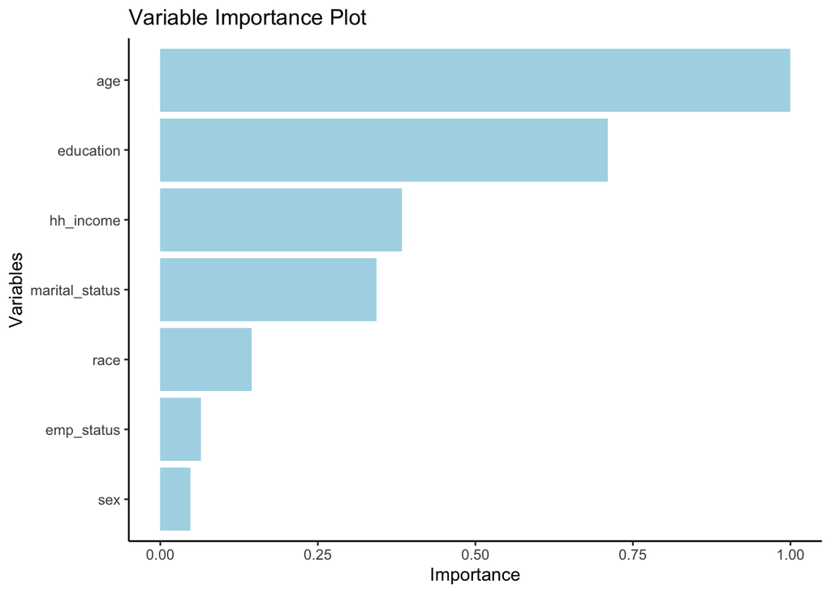

```r
# Variable importance
library(vip)

## Plotting variable importance
rf_fit %>%
  extract_fit_parsnip() %>%
  vip(num_features = 25) %>%
  .$data |>
  mutate(
    Importance = Importance / max(Importance),
    Variable = fct_reorder(.x = Importance, .f = Variable)) |>
  ggplot() +
  geom_col(
    aes(x = Importance,
        y = Variable),
    fill = "#add8e6") +
  labs(
    title = "Variable Importance Plot",
    y = "Variables") +
  theme_classic()
```

## Fitting the Model

Given that the random forest model had higher rates of accuracy, precision, and recall than the logistic regression model, we utilize the random forest model to fit the testing data. We fit the model on the testing data with income estimated from the microsimulation model under each of the policies. The first fit of the model is using income values estimated under the ARPA CTC policy. The second fit of the model is using income values estimated under the normal CTC policy.

### **Random Forest Testing - ASEC Individual Data (ARPA CTC Estimated Income)**

**Estimated Federal Voter Turnout Rate**

*Weights have been applied*

```r
# Under ARPA
arpa_testing <-
  asec_refactored %>%
  rename(
    hh_income_original = hh_income,
    hh_income = arpa_tot_inc) %>%
  select(
    -hh_income_original,
    -ctc_reg_tot_inc)

# Voter turnout rate - ARPA (Weights applied)

arpa_vote_predictions <-
  bind_cols(
    arpa_testing,
    predict(
      object = rf_fit,
      new_data = arpa_testing))

arpa_voted <-
  arpa_vote_predictions %>%
  filter(.pred_class == 1) %>%
  summarize(
    total = sum(weight)) %>%
  mutate(voted = "voted")

arpa_no_voted <-
  arpa_vote_predictions %>%
  filter(.pred_class == 2) %>%
  summarize(
    total = sum(weight)) %>%
  mutate(voted = "no vote")

arpa_turnout <-
  bind_rows(
    arpa_voted,
    arpa_no_voted) %>%
  pivot_wider(
    names_from = voted,
    values_from = total) %>%
  rename(no_vote = `no vote`) %>%
   summarize(
    turnout_rate = voted / (voted + no_vote)) %>%
  mutate(
    credit = "arpa_ctc")
arpa_turnout
```

```
# A tibble: 1 × 2
  turnout_rate credit
         <dbl> <chr>
1        0.785 arpa_ctc
```

### **Random Forest Testing - ASEC Individual Data (Normal CTC Estimated Income)**

**Estimated Federal Voter Turnout Rate**

*Weights have been applied*

```r
# Under normal CTC
ctc_testing <-
  asec_refactored %>%
  rename(
    hh_income_original = hh_income,
    hh_income = ctc_reg_tot_inc) %>%
  select(
    -hh_income_original,
    -arpa_tot_inc)

ctc_vote_predictions <-
  bind_cols(
    ctc_testing,
    predict(
      object = rf_fit,
      new_data = ctc_testing))

# Voter turnout rate - CTC (Weights applied)
ctc_voted <-
  ctc_vote_predictions %>%
  filter(.pred_class == 1) %>%
  summarize(
    total = sum(weight)) %>%
  mutate(voted = "voted")

ctc_no_voted <-
  ctc_vote_predictions %>%
  filter(.pred_class == 2) %>%
  summarize(
    total = sum(weight)) %>%
  mutate(voted = "no vote")

ctc_turnout <-
  bind_rows(
    ctc_voted,
    ctc_no_voted) %>%
  pivot_wider(
    names_from = voted,
    values_from = total) %>%
  rename(no_vote = `no vote`) %>%
   summarize(
    turnout_rate = voted / (voted + no_vote)) %>%
  mutate(
    credit = "normal_ctc")
ctc_turnout
```

```
# A tibble: 1 × 2
  turnout_rate credit
         <dbl> <chr>
1        0.784 normal_ctc
```

## **Results - Predicted Voter Turnout Rate**

**Estimated Federal Voter Turnout Rate Under Each Policy**

*Weights have been applied *

The plot below summarizes the estimated federal voter turnout rate with incomes under each policy. We find, as expected, that the turnout rate is the highest when individuals receive the expanded child tax credit under ARPA, however, the difference in the estimated federal voter turnout rate between the normal CTC and ARPA CTC is very small, suggesting that the while the expansion had an impact on the average income of individuals, it may not have had a very noticeable impact on voter turnout.

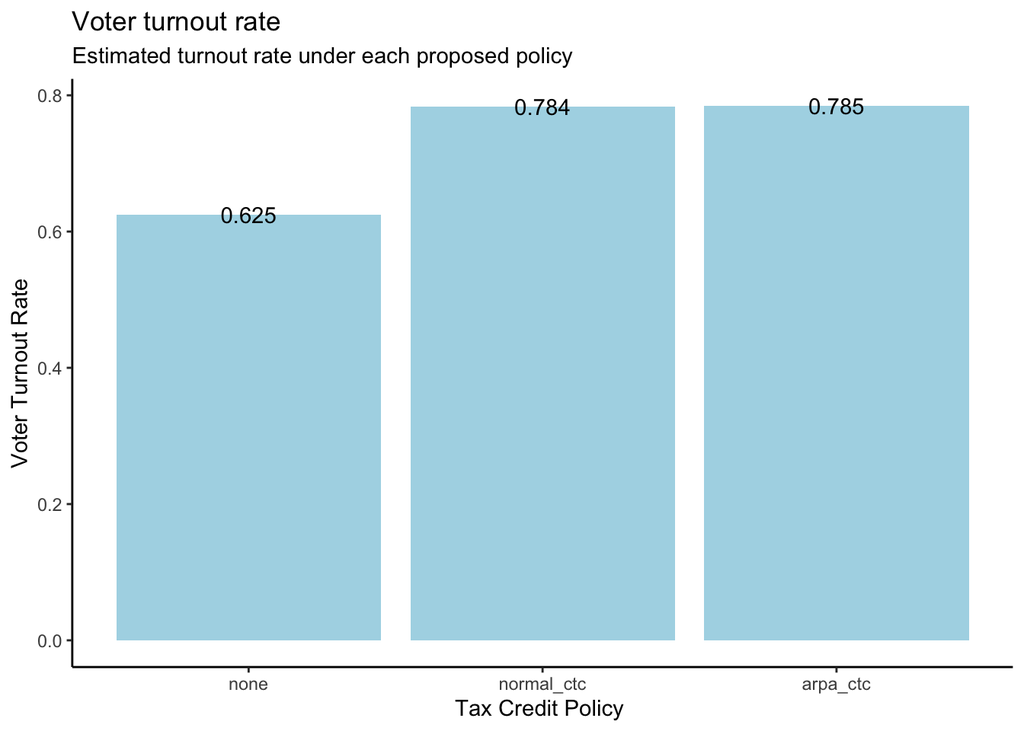

```r
# Voter turnout rate - CPS

cps_tot_vote <-
  cps %>%
  filter(voted == 1) %>%
  summarize(
    total = sum(weight)) %>%
  mutate(voted = "voted")

cps_tot_no_vote <-
  cps %>%
  filter(voted == 2) %>%
  summarize(
    total = sum(weight)) %>%
  mutate(voted = "no vote")

cps_tot_turnout <-
  bind_rows(
    cps_tot_vote,
    cps_tot_no_vote) %>%
  pivot_wider(
    names_from = voted,
    values_from = total) %>%
  rename(no_vote = `no vote`) %>%
   summarize(
    turnout_rate = voted / (voted + no_vote)) %>%
  mutate(
    credit = "none")


# Comparing turnout rates
turnout_combined <-
  bind_rows(cps_tot_turnout, arpa_turnout, ctc_turnout) %>%
  ggplot() +
  geom_col(
    aes(x = credit,
        y = turnout_rate),
    fill ="#add8e6") +
  geom_text(
    aes(x = credit,
        y = turnout_rate,
        label = round(turnout_rate, digits = 3))) +
  scale_x_discrete(
    limits = c("none", "normal_ctc", "arpa_ctc")) +
  labs(
    title = "Voter turnout rate",
    subtitle = "Estimated turnout rate under each proposed policy",
    x = "Tax Credit Policy ",
    y = "Voter Turnout Rate") +
  theme_classic()
turnout_combined
```

**Estimated Federal Voter Turnout Rate by Income Group Under Each Policy**

*Weights have been applied *

The plots below show the estimated voter turnout rates by income group under each policy. The table below also reflects this and calculates the difference in voter turnout rate by income level under each policy.

We estimate that overall, under both child tax credit policies, voter turnout rates are expected to increase across all income groups. We estimate the highest increase in voter turnout rates among the wealthiest income group. For the lowest income group, we also estimate a substantial increase in voter turnout under both policies, though, this increase is not as much as the wealthiest income category.

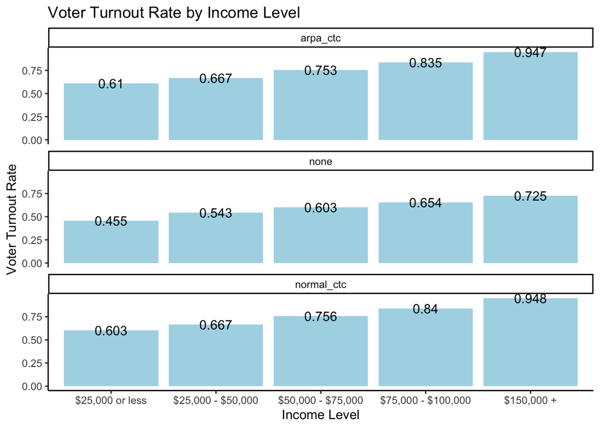

```r
# Voter turnout rate by income level - ARPA

arpa_inc_voted <-

  arpa_vote_predictions %>%

  mutate(
    inc_grouped =
      case_when(
        hh_income <= 7 ~ "$25,000 or less",
        hh_income <= 11 ~ "$25,000 - $50,000",
        hh_income <= 13 ~ "$50,000 - $75,000",
        hh_income == 14 ~ "$75,000 - $100,000",
        hh_income <= 16 ~ "$150,000 +")) %>%

  filter(.pred_class == 1) %>%

  summarize(
    total = sum(weight),
    .by = c(inc_grouped)) %>%

  mutate(voted = "voted")

arpa_inc_nv <-

  arpa_vote_predictions %>%

  mutate(
    inc_grouped =
      case_when(
        hh_income <= 7 ~ "$25,000 or less",
        hh_income <= 11 ~ "$25,000 - $50,000",
        hh_income <= 13 ~ "$50,000 - $75,000",
        hh_income == 14 ~ "$75,000 - $100,000",
        hh_income <= 16 ~ "$150,000 +")) %>%

    filter(.pred_class == 2) %>%

  summarize(
    total = sum(weight),
    .by = c(inc_grouped)) %>%

  mutate(voted = "no vote")

arpa_inc_turnout <-

  bind_rows(
    arpa_inc_voted,
    arpa_inc_nv) %>%

  arrange(inc_grouped) %>%

  pivot_wider(
    values_from = total,
    names_from = voted) %>%

  rename(
    voted = "voted",
    no_vote = `no vote`) %>%

  select(
    inc_grouped,
    voted,
    no_vote) %>%

  mutate(
    total_pop = voted + no_vote,
    turnout_rate = voted / total_pop) %>%

  mutate(
    inc_grouped = fct_reorder(inc_grouped, turnout_rate, .desc = FALSE)) %>%
  mutate(
    policy = "arpa_ctc")


# Voter turnout rate by income level - Normal CTC

ctc_inc_voted <-

  ctc_vote_predictions %>%

  mutate(
    inc_grouped =
      case_when(
        hh_income <= 7 ~ "$25,000 or less",
        hh_income <= 11 ~ "$25,000 - $50,000",
        hh_income <= 13 ~ "$50,000 - $75,000",
        hh_income == 14 ~ "$75,000 - $100,000",
        hh_income <= 16 ~ "$150,000 +")) %>%

  filter(.pred_class == 1) %>%

  summarize(
    total = sum(weight),
    .by = c(inc_grouped)) %>%

  mutate(voted = "voted")

ctc_inc_nv <-

  ctc_vote_predictions %>%

  mutate(
    inc_grouped =
      case_when(
        hh_income <= 7 ~ "$25,000 or less",
        hh_income <= 11 ~ "$25,000 - $50,000",
        hh_income <= 13 ~ "$50,000 - $75,000",
        hh_income == 14 ~ "$75,000 - $100,000",
        hh_income <= 16 ~ "$150,000 +")) %>%

    filter(.pred_class == 2) %>%

  summarize(
    total = sum(weight),
    .by = c(inc_grouped)) %>%

  mutate(voted = "no vote")

ctc_inc_turnout <-

  bind_rows(
    ctc_inc_voted,
    ctc_inc_nv) %>%

  arrange(inc_grouped) %>%

  pivot_wider(
    values_from = total,
    names_from = voted) %>%

  rename(
    voted = "voted",
    no_vote = `no vote`) %>%

  select(
    inc_grouped,
    voted,
    no_vote) %>%

  mutate(
    total_pop = voted + no_vote,
    turnout_rate = voted / total_pop) %>%

  mutate(
    inc_grouped = fct_reorder(inc_grouped, turnout_rate, .desc = FALSE)) %>%

  mutate(policy = "normal_ctc")

# Change in turnout by group
cps_turnout <-
  cps_turnout %>%
  mutate(policy = "none")

# Combining
total_turnout <-
  bind_rows(
    cps_turnout,
    arpa_inc_turnout,
    ctc_inc_turnout)

# Plotting

total_turnout %>%

  ggplot() +

  geom_col(
    aes(
      x = inc_grouped,
      y = turnout_rate),
     fill = "#add8e6") +

  geom_text(
    aes(x = inc_grouped,
        y = turnout_rate,
        label = round(turnout_rate, digits = 3))) +

  labs(
    title = "Voter Turnout Rate by Income Level",
    x = "Income Level",
    y = "Voter Turnout Rate") +

  theme_classic() +
  facet_wrap(
    facets = "policy",
    nrow = 3)
```

**Estimated Change in Federal Voter Turnout Rate Under Each Policy by Income Group**

*Weights have been applied *

```r
turnout <-
  total_turnout %>%
  select(inc_grouped, turnout_rate, policy) %>%
  arrange(-turnout_rate) %>%
  pivot_wider(
    values_from = turnout_rate,
    names_from = policy) %>%
  mutate(arpa_ctc_diff = arpa_ctc - none) %>%
  mutate(normal_ctc_diff = normal_ctc - none) %>%
  select(
         inc_grouped,
         none,
         normal_ctc,
         arpa_ctc,
         normal_ctc_diff,
         arpa_ctc_diff) %>%
  kableExtra::kable()
turnout
```

| inc_grouped | none | normal_ctc | arpa_ctc | normal_ctc_diff | arpa_ctc_diff |
| --- | --- | --- | --- | --- | --- |
| $150,000 + | 0.7246655 | 0.9481233 | 0.9473910 | 0.2234578 | 0.2227255 |
| $75,000 - $100,000 | 0.6537254 | 0.8396580 | 0.8352895 | 0.1859326 | 0.1815641 |
| $50,000 - $75,000 | 0.6031457 | 0.7560414 | 0.7526941 | 0.1528957 | 0.1495485 |
| $25,000 - $50,000 | 0.5431419 | 0.6668432 | 0.6668319 | 0.1237013 | 0.1236899 |
| $25,000 or less | 0.4551275 | 0.6031317 | 0.6102445 | 0.1480042 | 0.1551169 |